# R Group Project-Cleaning data

kangwei

October 28, 2018

## Stock datasets

The dataset selected is a stock datasets. It contain details about some stocks that have been collected over several years, 2012 to 2017. The dataset for the stocks are stored on 20 CSV files. There is another CSV file namely securities.csv that contains the information about the stock companies.

First the 20 csv files are loaded at once and rbind the data frames together, since they have the same columns.

However, not all the columns names in the files are identical, different files have some differences in spacing. The data frames can’t be rbind if the column names are not identical. Therefore, the column names are given in a vector rather than using what is given on the CSV files. With the same column names for all the dataframes, then it can be rbind into a single dataframe.

### Load the dataset

```r
setwd('./nyse-financial-stocks/')
files <- list.files(pattern = "*.csv")
# The column names for the imported stock datasets
stockCol <- c("Date", "Stock", "Location", "High", "Low", "Open", "Close",
              "Aggregated data 2 days", "Aggregated data 3 days", "Aggregated data 5 days",
              "Volume", "Number of employees", "Net change 0-numeric", "Net change 0-nominal",
              "Net change 5-numeric", "Net change 5-nominal", "Net change 25-numeric",
              "Net change 25-nominal")
# Read the 20 source files and merge them into a single dataframe
stockDf <- do.call(rbind, lapply(files, function(x) read.csv(x, stringsAsFactors = FALSE,
                                                             header = TRUE, col.names = stockCol)))

# The column names for the imported company dataset
companyCol <- c('Stock', 'Company', 'SEC filings', 'GICS Sector', 'GICS Sub Industry', 'HQ Address',
                'Date first added', 'CIK')
companyDetails <- read.csv('../securities.csv', stringsAsFactors = FALSE, col.names = companyCol)
```

Dimension of the dataset loaded

```r
dim(stockDf)
```

```
## [1] 25180    18
```

```r
dim(companyDetails)
```

```
## [1] 505   8
```

Structure of the *stock* data frame

```r
str(stockDf)
```

```
## 'data.frame':    25180 obs. of  18 variables:
##  $ Date                  : chr  "30/11/2012" "3/12/2012" "4/12/2012" "5/12/2012" ...
##  $ Stock                 : chr  "AXP" "AXP" "AXP" "AXP" ...
##  $ Location              : chr  "New York" "New York" "New York" "New York" ...
##  $ High                  : num  56.1 56.5 56.2 56.7 56.3 ...
##  $ Low                   : num  55.7 55.9 55.5 55.8 55.9 ...
##  $ Open                  : num  55.9 56.1 55.9 55.9 56.3 ...
##  $ Close                 : num  55.9 56 55.8 56.4 56.1 ...
##  $ Aggregated.data.2.days: num  56 55.9 56.1 56.3 56.4 ...
##  $ Aggregated.data.3.days: num  55.9 56.1 56.1 56.4 56.5 ...
##  $ Aggregated.data.5.days: num  56 56.2 56.3 56.6 56.8 ...
##  $ Volume                : num  5716100 4954600 3912300 5667500 3854400 ...
##  $ Number.of.employees   : chr  "56,400" "56,400" "56,400" "56,400" ...
##  $ Net.change.0.numeric  : num  0.04 -0.1 -0.06 0.51 -0.18 0.36 0.08 0.06 0.32 0.06 ...
##  $ Net.change.0.nominal  : chr  "Positive" "Negative" "Negative" "Positive" ...
##  $ Net.change.5.numeric  : num  0.26 0.52 0.85 1.17 1.37 1.47 -0.02 0.27 0.47 -0.87 ...
##  $ Net.change.5.nominal  : chr  "Positive" "Positive" "Positive" "Positive" ...
##  $ Net.change.25.numeric : num  4 4.11 4.36 4.9 4.94 4.96 4.09 3.62 3.39 2.12 ...
##  $ Net.change.25.nominal : chr  "Positive" "Positive" "Positive" "Positive" ...
```

Date column is not in date format.  
Number of employees column is in character, not numeric.

Structure of the *company details* data frame

```r
str(companyDetails)
```

```
## 'data.frame':    505 obs. of  8 variables:
##  $ Stock            : chr  "MMM" "ABT" "ABBV" "ACN" ...
##  $ Company          : chr  "3M Company" "Abbott Laboratories" "AbbVie" "Accenture plc" ...
##  $ SEC.filings      : chr  "reports" "reports" "reports" "reports" ...
##  $ GICS.Sector      : chr  "Industrials" "Health Care" "Health Care" "Information Technology" ...
##  $ GICS.Sub.Industry: chr  "Industrial Conglomerates" "Health Care Equipment" "Pharmaceuticals" "IT Consulting & Other Services" ...
##  $ HQ.Address       : chr  "St. Paul, Minnesota" "North Chicago, Illinois" "North Chicago, Illinois" "Dublin, Ireland" ...
##  $ Date.first.added : chr  "" "31/3/1964" "31/12/2012" "6/7/2011" ...
##  $ CIK              : int  66740 1800 1551152 1467373 718877 1144215 796343 1158449 874761 1122304 ...
```

Date first added is not in date format.

### Fix the format of the data

Fix the date formats in the dataset

```r
stockDf$Date <- dmy(stockDf$Date)

companyDetails$Date.first.added <- dmy(companyDetails$Date.first.added)
```

Fix the number of employees format into numeric

```r
stockDf$Number.of.employees <- str_replace(stockDf$Number.of.employees, pattern = ',', replacement = '')
stockDf$Number.of.employees <- as.numeric(stockDf$Number.of.employees)
```

Some of the text would be better if formatted into factors

```r
stockDf$Net.change.0.nominal <- as.factor(stockDf$Net.change.0.nominal)
stockDf$Net.change.5.nominal <- as.factor(stockDf$Net.change.5.nominal)
stockDf$Net.change.25.nominal <- as.factor(stockDf$Net.change.25.nominal)

companyDetails$SEC.filings <- as.factor(companyDetails$SEC.filings)
companyDetails$GICS.Sector <- as.factor(companyDetails$GICS.Sector)
companyDetails$GICS.Sub.Industry <- as.factor(companyDetails$GICS.Sub.Industry)

levels(stockDf$Net.change.0.nominal) <- c("Unknown", "Equal", "Negative", "Positive")
levels(stockDf$Net.change.5.nominal) <- c("Unknown", "Equal", "Negative", "Positive")
levels(stockDf$Net.change.25.nominal) <- c("Unknown", "Equal", "Negative", "Positive")

levels(stockDf$Net.change.0.nominal)
```

```
## [1] "Unknown"  "Equal"    "Negative" "Positive"
```

```r
levels(stockDf$Net.change.5.nominal)
```

```
## [1] "Unknown"  "Equal"    "Negative" "Positive"
```

```r
levels(stockDf$Net.change.25.nominal)
```

```
## [1] "Unknown"  "Equal"    "Negative" "Positive"
```

```r
levels(companyDetails$SEC.filings)
```

```
## [1] "reports"
```

```r
levels(companyDetails$GICS.Sector)
```

```
##  [1] "Consumer Discretionary"      "Consumer Staples"
##  [3] "Energy"                      "Financials"
##  [5] "Health Care"                 "Industrials"
##  [7] "Information Technology"      "Materials"
##  [9] "Real Estate"                 "Telecommunications Services"
## [11] "Utilities"
```

```r
levels(companyDetails$GICS.Sub.Industry)
```

```
##   [1] "Advertising"
##   [2] "Aerospace & Defense"
##   [3] "Agricultural Products"
##   [4] "Air Freight & Logistics"
##   [5] "Airlines"
##   [6] "Alternative Carriers"
##   [7] "Apparel Retail"
##   [8] "Apparel, Accessories & Luxury Goods"
##   [9] "Application Software"
##  [10] "Asset Management & Custody Banks"
##  [11] "Auto Parts & Equipment"
##  [12] "Automobile Manufacturers"
##  [13] "Automotive Retail"
##  [14] "Banks"
##  [15] "Biotechnology"
```

[output cut: 109 more lines]

Check the structure of the data after converting

```r
str(stockDf)
```

```
## 'data.frame':    25180 obs. of  18 variables:
##  $ Date                  : Date, format: "2012-11-30" "2012-12-03" ...
##  $ Stock                 : chr  "AXP" "AXP" "AXP" "AXP" ...
##  $ Location              : chr  "New York" "New York" "New York" "New York" ...
##  $ High                  : num  56.1 56.5 56.2 56.7 56.3 ...
##  $ Low                   : num  55.7 55.9 55.5 55.8 55.9 ...
##  $ Open                  : num  55.9 56.1 55.9 55.9 56.3 ...
##  $ Close                 : num  55.9 56 55.8 56.4 56.1 ...
##  $ Aggregated.data.2.days: num  56 55.9 56.1 56.3 56.4 ...
##  $ Aggregated.data.3.days: num  55.9 56.1 56.1 56.4 56.5 ...
##  $ Aggregated.data.5.days: num  56 56.2 56.3 56.6 56.8 ...
##  $ Volume                : num  5716100 4954600 3912300 5667500 3854400 ...
##  $ Number.of.employees   : num  56400 56400 56400 56400 56400 56400 56400 56400 56400 56400 ...
##  $ Net.change.0.numeric  : num  0.04 -0.1 -0.06 0.51 -0.18 0.36 0.08 0.06 0.32 0.06 ...
##  $ Net.change.0.nominal  : Factor w/ 4 levels "Unknown","Equal",..: 4 3 3 4 3 4 4 4 4 4 ...
##  $ Net.change.5.numeric  : num  0.26 0.52 0.85 1.17 1.37 1.47 -0.02 0.27 0.47 -0.87 ...
##  $ Net.change.5.nominal  : Factor w/ 4 levels "Unknown","Equal",..: 4 4 4 4 4 4 2 4 4 3 ...
##  $ Net.change.25.numeric : num  4 4.11 4.36 4.9 4.94 4.96 4.09 3.62 3.39 2.12 ...
##  $ Net.change.25.nominal : Factor w/ 4 levels "Unknown","Equal",..: 4 4 4 4 4 4 4 4 4 4 ...
```

```r
str(companyDetails)
```

```
## 'data.frame':    505 obs. of  8 variables:
##  $ Stock            : chr  "MMM" "ABT" "ABBV" "ACN" ...
##  $ Company          : chr  "3M Company" "Abbott Laboratories" "AbbVie" "Accenture plc" ...
##  $ SEC.filings      : Factor w/ 1 level "reports": 1 1 1 1 1 1 1 1 1 1 ...
##  $ GICS.Sector      : Factor w/ 11 levels "Consumer Discretionary",..: 6 5 5 7 7 6 7 1 11 5 ...
##  $ GICS.Sub.Industry: Factor w/ 124 levels "Advertising",..: 67 51 96 77 56 39 9 13 66 81 ...
##  $ HQ.Address       : chr  "St. Paul, Minnesota" "North Chicago, Illinois" "North Chicago, Illinois" "Dublin, Ireland" ...
##  $ Date.first.added : Date, format: NA "1964-03-31" ...
##  $ CIK              : int  66740 1800 1551152 1467373 718877 1144215 796343 1158449 874761 1122304 ...
```

The incorrect data formats are now correctly represented.

### View the data

```r
kable(head(stockDf, 10), format="markdown")
```

| Date | Stock | Location | High | Low | Open | Close | Aggregated.data.2.days | Aggregated.data.3.days | Aggregated.data.5.days | Volume | Number.of.employees | Net.change.0.numeric | Net.change.0.nominal | Net.change.5.numeric | Net.change.5.nominal | Net.change.25.numeric | Net.change.25.nominal |
| --- | --- | --- | --- | --- | --- | --- | --- | --- | --- | --- | --- | --- | --- | --- | --- | --- | --- |
| 2012-11-30 | AXP | New York | 56.09 | 55.71 | 55.86 | 55.90 | 55.95 | 55.91 | 56.05 | 5716100 | 56400 | 0.04 | Positive | 0.26 | Positive | 4.00 | Positive |
| 2012-12-03 | AXP | New York | 56.53 | 55.93 | 56.09 | 55.99 | 55.92 | 56.08 | 56.19 | 4954600 | 56400 | -0.10 | Negative | 0.52 | Positive | 4.11 | Positive |
| 2012-12-04 | AXP | New York | 56.19 | 55.47 | 55.90 | 55.84 | 56.12 | 56.12 | 56.34 | 3912300 | 56400 | -0.06 | Negative | 0.85 | Positive | 4.36 | Positive |
| 2012-12-05 | AXP | New York | 56.66 | 55.75 | 55.89 | 56.40 | 56.26 | 56.38 | 56.59 | 5667500 | 56400 | 0.51 | Positive | 1.17 | Positive | 4.90 | Positive |
| 2012-12-06 | AXP | New York | 56.33 | 55.88 | 56.30 | 56.12 | 56.37 | 56.49 | 56.84 | 3854400 | 56400 | -0.18 | Negative | 1.37 | Positive | 4.94 | Positive |
| 2012-12-07 | AXP | New York | 56.64 | 56.20 | 56.25 | 56.61 | 56.68 | 56.81 | 57.16 | 3689200 | 56400 | 0.36 | Positive | 1.47 | Positive | 4.96 | Positive |
| 2012-12-10 | AXP | New York | 56.95 | 56.42 | 56.67 | 56.75 | 56.91 | 57.16 | 57.17 | 3784000 | 56400 | 0.08 | Positive | -0.02 | Equal | 4.09 | Positive |
| 2012-12-11 | AXP | New York | 57.59 | 56.92 | 57.00 | 57.06 | 57.36 | 57.48 | 57.27 | 4342800 | 56400 | 0.06 | Positive | 0.27 | Positive | 3.62 | Positive |
| 2012-12-12 | AXP | New York | 58.35 | 57.18 | 57.35 | 57.67 | 57.69 | 57.35 | 57.43 | 5941700 | 56400 | 0.32 | Positive | 0.47 | Positive | 3.39 | Positive |
| 2012-12-13 | AXP | New York | 58.00 | 57.50 | 57.66 | 57.72 | 57.19 | 57.21 | 57.25 | 4725900 | 56400 | 0.06 | Positive | -0.87 | Negative | 2.12 | Positive |

```r
kable(head(companyDetails, 10, format='markdown'))
```

| Stock | Company | SEC.filings | GICS.Sector | GICS.Sub.Industry | HQ.Address | Date.first.added | CIK |
| --- | --- | --- | --- | --- | --- | --- | --- |
| MMM | 3M Company | reports | Industrials | Industrial Conglomerates | St. Paul, Minnesota | NA | 66740 |
| ABT | Abbott Laboratories | reports | Health Care | Health Care Equipment | North Chicago, Illinois | 1964-03-31 | 1800 |
| ABBV | AbbVie | reports | Health Care | Pharmaceuticals | North Chicago, Illinois | 2012-12-31 | 1551152 |
| ACN | Accenture plc | reports | Information Technology | IT Consulting & Other Services | Dublin, Ireland | 2011-07-06 | 1467373 |
| ATVI | Activision Blizzard | reports | Information Technology | Home Entertainment Software | Santa Monica, California | 2015-08-31 | 718877 |
| AYI | Acuity Brands Inc | reports | Industrials | Electrical Components & Equipment | Atlanta, Georgia | 2016-05-03 | 1144215 |
| ADBE | Adobe Systems Inc | reports | Information Technology | Application Software | San Jose, California | 1997-05-05 | 796343 |
| AAP | Advance Auto Parts | reports | Consumer Discretionary | Automotive Retail | Roanoke, Virginia | 2015-07-09 | 1158449 |
| AES | AES Corp | reports | Utilities | Independent Power Producers & Energy Traders | Arlington, Virginia | NA | 874761 |
| AET | Aetna Inc | reports | Health Care | Managed Health Care | Hartford, Connecticut | 1976-06-30 | 1122304 |

### NAs management

Check if the data has NA

```r
sum(is.na(stockDf))
```

```
## [1] 575
```

```r
sum(is.na(companyDetails))
```

```
## [1] 198
```

Cleansing the NAs of the stock dataframe

```r
# stockDf[!complete.cases(stockDf),]
nrow(stockDf[!complete.cases(stockDf),])
```

```
## [1] 495
```

```r
# Most of the NAs are from the column Net.change.25.numeric
sum(is.na(stockDf$Net.change.25.numeric))
```

```
## [1] 495
```

```r
# Fill in the NAs with the mean from the column
stockDf$Net.change.25.numeric[is.na(stockDf$Net.change.25.numeric)] <- mean(stockDf$Net.change.25.numeric,
                                                                            na.rm=T)
# Another column with NAs
sum(is.na(stockDf$Net.change.5.numeric))
```

```
## [1] 80
```

```r
stockDf$Net.change.5.numeric[is.na(stockDf$Net.change.5.numeric)] <- mean(stockDf$Net.change.5.numeric,
                                                                            na.rm=T)
```

Cleansing the NAs of the company dataframe

```r
# Find the NAs in the company dataframe
# companyDetails[!complete.cases(companyDetails),]
nrow(companyDetails[!complete.cases(companyDetails),])
```

```
## [1] 198
```

```r
sum(is.na(companyDetails$Date.first.added))
```

```
## [1] 198
```

```r
# Replace the NAs with the date column with a date
companyDetails$Date.first.added[is.na(companyDetails$Date.first.added)] <- dmy('01-01-1970')
```

Check if all the NAs are removed

```r
sum(is.na(stockDf))
```

```
## [1] 0
```

```r
sum(is.na(companyDetails))
```

```
## [1] 0
```

### Pre-analysis

Check the number of distinct stocks in the dataset

```r
unique(stockDf$Stock)
```

```
##  [1] "AXP"  "BAC"  "BBT"  "C"    "CMA"  "COF"  "DFS"  "FITB" "GS"   "JPM"
## [11] "KEY"  "MS"   "MTB"  "PBCT" "PNC"  "SCHW" "STI"  "STT"  "USB"  "WFC"
```

```r
length(unique(stockDf$Stock))
```

```
## [1] 20
```

```r
unique(companyDetails$Stock)
```

```
##   [1] "MMM"   "ABT"   "ABBV"  "ACN"   "ATVI"  "AYI"   "ADBE"  "AAP"
##   [9] "AES"   "AET"   "AMG"   "AFL"   "A"     "APD"   "AKAM"  "ALK"
##  [17] "ALB"   "ALXN"  "ALLE"  "AGN"   "ADS"   "LNT"   "ALL"   "GOOGL"
##  [25] "GOOG"  "MO"    "AMZN"  "AEE"   "AAL"   "AEP"   "AXP"   "AIG"
##  [33] "AMT"   "AWK"   "AMP"   "ABC"   "AME"   "AMGN"  "APH"   "APC"
##  [41] "ADI"   "ANTM"  "AON"   "APA"   "AIV"   "AAPL"  "AMAT"  "ADM"
##  [49] "ARNC"  "AJG"   "AIZ"   "T"     "ADSK"  "ADP"   "AN"    "AZO"
##  [57] "AVB"   "AVY"   "BHI"   "BLL"   "BAC"   "BCR"   "BAX"   "BBT"
##  [65] "BDX"   "BBBY"  "BRK.B" "BBY"   "BIIB"  "BLK"   "HRB"   "BA"
##  [73] "BWA"   "BXP"   "BSX"   "BMY"   "AVGO"  "BF.B"  "CHRW"  "CA"
##  [81] "COG"   "CPB"   "COF"   "CAH"   "KMX"   "CCL"   "CAT"   "CBG"
##  [89] "CBS"   "CELG"  "CNC"   "CNP"   "CTL"   "CERN"  "CF"    "SCHW"
##  [97] "CHTR"  "CHK"   "CVX"   "CMG"   "CB"    "CHD"   "CI"    "XEC"
## [105] "CINF"  "CTAS"  "CSCO"  "C"     "CFG"   "CTXS"  "CME"   "CMS"
## [113] "COH"   "KO"    "CTSH"  "CL"    "CMCSA" "CMA"   "CAG"   "CXO"
```

[output cut: 49 more lines]

```r
length(unique(companyDetails$Stock))
```

```
## [1] 505
```

Functions to get stock details

```r
# Function  to get stock details
getCompanyDetails <- function(tickerSym) {
  stock <- companyDetails[which(companyDetails$Stock==tickerSym),]
  return(stock)
}

getCompanyName <- function(tickerSym) {
  companyName <- companyDetails[which(companyDetails$Stock==tickerSym),]$Company
  return(companyName)
}

getCompanyDetails(tickerSym = 'AXP')
```

```
##    Stock             Company SEC.filings GICS.Sector GICS.Sub.Industry
## 31   AXP American Express Co     reports  Financials  Consumer Finance
##            HQ.Address Date.first.added  CIK
## 31 New York, New York       1976-06-30 4962
```

```r
getCompanyDetails(tickerSym = 'BAC')
```

```
##    Stock              Company SEC.filings GICS.Sector GICS.Sub.Industry
## 61   BAC Bank of America Corp     reports  Financials             Banks
##                   HQ.Address Date.first.added   CIK
## 61 Charlotte, North Carolina       1976-06-30 70858
```

```r
getCompanyDetails('C')
```

```
##     Stock        Company SEC.filings GICS.Sector GICS.Sub.Industry
## 108     C Citigroup Inc.     reports  Financials             Banks
##             HQ.Address Date.first.added    CIK
## 108 New York, New York       1988-05-31 831001
```

```r
getCompanyName(tickerSym = 'AXP')
```

```
## [1] "American Express Co"
```

```r
getCompanyName(tickerSym = 'ABT')
```

```
## [1] "Abbott Laboratories"
```

```r
getCompanyName(tickerSym = 'ALB')
```

```
## [1] "Albemarle Corp"
```

### Merge the dataset

```r
stockData <- left_join(stockDf, companyDetails, by = c('Stock'))
colnames(stockData)
```

```
##  [1] "Date"                   "Stock"
##  [3] "Location"               "High"
##  [5] "Low"                    "Open"
##  [7] "Close"                  "Aggregated.data.2.days"
##  [9] "Aggregated.data.3.days" "Aggregated.data.5.days"
## [11] "Volume"                 "Number.of.employees"
## [13] "Net.change.0.numeric"   "Net.change.0.nominal"
## [15] "Net.change.5.numeric"   "Net.change.5.nominal"
## [17] "Net.change.25.numeric"  "Net.change.25.nominal"
## [19] "Company"                "SEC.filings"
## [21] "GICS.Sector"            "GICS.Sub.Industry"
## [23] "HQ.Address"             "Date.first.added"
## [25] "CIK"
```

### Remove some columns

```r
stockData <- select(stockData, c("Date", "Stock", "High", "Low", "Open", "Close",
                                 "Volume", "Company", "GICS.Sector", "GICS.Sub.Industry",
                                 "Net.change.0.numeric", "Net.change.0.nominal"))
# Rename the columns
names(stockData) <- c("Date", "StockCode", "High", "Low", "Open", "Close", "Volume", "Company",
                      "Sector", "SubIndustry", "NetChange", "NetChangeNominal")
colnames(stockData)
```

```
##  [1] "Date"             "StockCode"        "High"
##  [4] "Low"              "Open"             "Close"
##  [7] "Volume"           "Company"          "Sector"
## [10] "SubIndustry"      "NetChange"        "NetChangeNominal"
```

### View the finalize dataset

```r
kable(head(stockData, 10), format="markdown")
```

| Date | StockCode | High | Low | Open | Close | Volume | Company | Sector | SubIndustry | NetChange | NetChangeNominal |
| --- | --- | --- | --- | --- | --- | --- | --- | --- | --- | --- | --- |
| 2012-11-30 | AXP | 56.09 | 55.71 | 55.86 | 55.90 | 5716100 | American Express Co | Financials | Consumer Finance | 0.04 | Positive |
| 2012-12-03 | AXP | 56.53 | 55.93 | 56.09 | 55.99 | 4954600 | American Express Co | Financials | Consumer Finance | -0.10 | Negative |
| 2012-12-04 | AXP | 56.19 | 55.47 | 55.90 | 55.84 | 3912300 | American Express Co | Financials | Consumer Finance | -0.06 | Negative |
| 2012-12-05 | AXP | 56.66 | 55.75 | 55.89 | 56.40 | 5667500 | American Express Co | Financials | Consumer Finance | 0.51 | Positive |
| 2012-12-06 | AXP | 56.33 | 55.88 | 56.30 | 56.12 | 3854400 | American Express Co | Financials | Consumer Finance | -0.18 | Negative |
| 2012-12-07 | AXP | 56.64 | 56.20 | 56.25 | 56.61 | 3689200 | American Express Co | Financials | Consumer Finance | 0.36 | Positive |
| 2012-12-10 | AXP | 56.95 | 56.42 | 56.67 | 56.75 | 3784000 | American Express Co | Financials | Consumer Finance | 0.08 | Positive |
| 2012-12-11 | AXP | 57.59 | 56.92 | 57.00 | 57.06 | 4342800 | American Express Co | Financials | Consumer Finance | 0.06 | Positive |
| 2012-12-12 | AXP | 58.35 | 57.18 | 57.35 | 57.67 | 5941700 | American Express Co | Financials | Consumer Finance | 0.32 | Positive |
| 2012-12-13 | AXP | 58.00 | 57.50 | 57.66 | 57.72 | 4725900 | American Express Co | Financials | Consumer Finance | 0.06 | Positive |

### Function to visualize the data

Function to plot the closing price

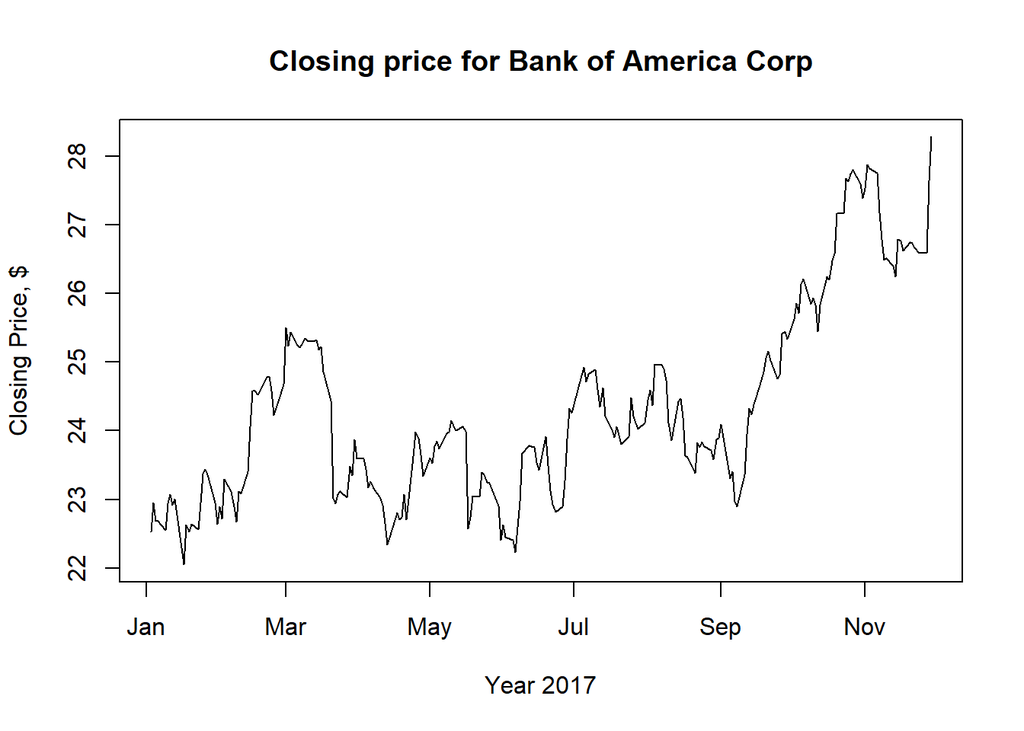

```r
plotClosing <- function(code) {
  subStock <- stockData %>% filter(StockCode==code, Date >= dmy('01-01-2017'))
  plot(x = subStock$Date, y = subStock$Close, main=paste("Closing price for", getCompanyName(code)),
       xlab="Year 2017", ylab="Closing Price, $", type='l')
}

plotClosing(code="BAC")
```

[figure not shown]

```r
plotHighLowDiff <- function(code) {
  subStock <- stockData %>% filter(StockCode==code, Date >= dmy('01-01-2017'))
  plot(x = subStock$Date, y = subStock$HighLowDiff, main = paste("High-Low Difference for", getCompanyName(code)), xlab = 'Year 2017', ylab = 'High-Low Difference, $', type = 'l')
}

plotHighLowDiff(code='BAC')
```